# LOGM 655 - Examples

Named Entity Recognition

MAJ Bryan Kolano, 2d Lt Nate Beveridge, 2d Lt Zachary Kane

26 Nov 2018

28 Nov 2018

# Introduction

## Motivation

Suppose we care to extract the people, organizations, or locations mentioned in a particular section of text and how they relate to each other in the context of the document. In the Harry Potter texts, we could attempt to gain insight about particular chapters or particular books when looking at which named entities are mentioned the most, when they are mentioned, or what other entities (or particular parts of speech) are mentioned in close sequence.

In Bryan’s project, he is looking at the last 25 years’ worth of State of the Union Addresses to see what trends exist across presidents and parties. In addition to document summarization to generate a condensed version of each speech and topic modeling to “decode” the different common topics across the speeches, he could further analyze the text to see who and what each president mentions, how often, and in what context.

The goal of Named Entity Recognition (NER) is the process of finding spans of text that constitute proper name then classify the type of entity. Named entities are anything that can be referred to with a proper noun: a person, a location, or an organization. They have also been extended to include dates, times, and numerical expressions. Named entities can give insight to events in text, relationship between people in a text, and aid in other text mining techniques. For example, we may want to conduct sentiment analysis towards a certain entity. The following table displays a list of generic named entity types with the kind of entities they refer to.

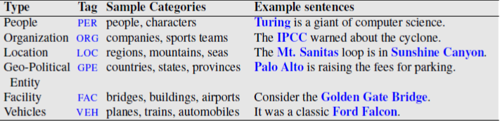

Let’s take one in class exercise and see what entities we come up with, and see what challenges and potential other text mining techniques we could use after NER.

One further example:

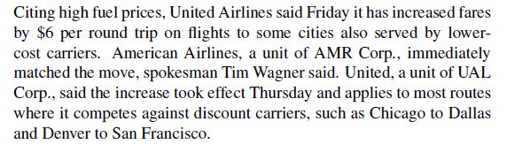

The example shown above blends NER, event coreference (which events mentioned in a document are the same event), temporal expressions (days of the weeks, months), entity linking (United Airlines vs. United). While this lesson only delves into NER, this example shows some of the things that could be extracted to answer a question like: “Is there any relationship between one airline changing fare price followed by others doing to same thing?”

With the United Airlines example above, NER can break it down into the following entities based on their entity type.

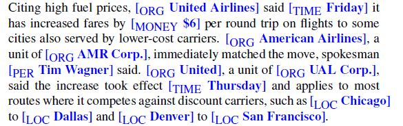

There are challenges when trying to perform named entity recognition. It is difficult to segment the text correctly to identify what is and isn’t an entity. It is also hard to identify the type of entity for a given word. For example, the entity JFK could be used for the airport, a person, schools, bridges, street names, or even a movie.

## NER as Sequence Labeling

A word-by-word sequence labeling task is the most common algorithm for performing NER. Sequence labeling is simply trying to assign a label to each element of a sequence chosen from a small fixed set of labels. The assigned tags capture both the boundary and the entity type. There are two formats that entities can be tagged: IOB and IO tagging. IOB tagging introduces a tag for the beginning (B) and inside (I) of each entity type, and one for tokens outside (O). This results in *2n+1* tags for *n* entities. IO tagging doesn’t identify the B tags, and thus isn’t able to distinguish between two entities of the same type right next to one another. This is rarer so typically IO tags are sufficient. IO tagging is simpler as it only produces *n+1* tags. Below we’ll see a sentence broken down into IOB and IO tagged entities.

[ORG **American Airlines**], a unit of [ORG **AMR Corp.**], immediately matched the move, spokesman [PER **Tim Wagner**] said.

This sentence is tagged and below are the associated IOB and IO labels broken down.

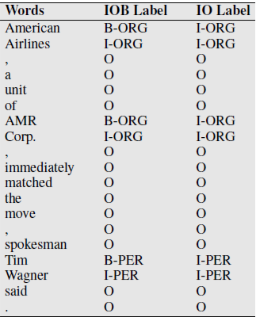

The next sections all cover the standard algorithms for NER.

# Types of NER

## Feature-based NER

These algorithms use various features as inputs/predictors for the labeling of entity tags, similar to PoS tagging. Some common features are word shape, gazetteer presence (binary), prefix/suffix, words within a given window of the word in question (context), and sometimes POS although some researchers find this not to be a useful feature. Word shape features represent the letter patterns of a word by mapping lower-case letters to ‘x’, upper case letters to ‘X’, numbers/digits to ‘d’, and retaining punctuation.

For example ‘I.M.F’ would be represented as X.X.X and ‘DC10-30’ would be represented as XXdd-dd.

Gazetteers act as entity type dictionaries. In practice this means that membership to a gazetteer acts as a binary feature in that if a word matches an entry in a list of locations then its membership adds to the probability that the word will be tagged as a location. The effectiveness of gazetteers varies greatly from situation to situation and they can be very difficult to maintain.

Prefixes and suffixes are also used as word features, as well as word embeddings (mapping of words to vectors) or the word in question and neighboring words, word identities of the word in question and neighboring words.

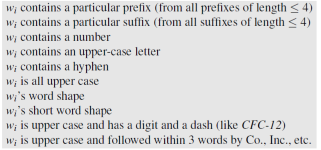

The first model that is commonly used for this task is the Maximum Entropy Markov Model (MEMM). Just as with POS tagging, MEMMs are preferred to HMMs due to the fact that they are discriminative as opposed to generative. Additionally, it is far easier to incorporate the use of many features in predicting tags since they compute the posterior directly (intuition for this is found in Jurafsky pg. 168). Additionally, the MEMM model relaxes the assumption of tag independence present in HMMs.

Conditional Random Fields (CRFs) are the other commonly used feature-based model; it is also discriminative and does not assume independence between tags. CRFs have a number of advantages over MEMMs; they are able to take into account future words/features, as well as address the label bias problem inherent in MEMMs. The label bias problem arises because transitions out of any one state to the next compete only against one another, making it so that there is a bias toward states with few transition arcs. Conditional random fields normalize transition probabilities globally over entire sequence which eliminates the label bias problem.

Very generally, CRFs can be thought of as F:X–>Y, a function F takes a set of features X and assigns probabilities of membership to a various tag types Y. The function does not act time step by step but rather acts over a window of tokens allowing it to utilize context.

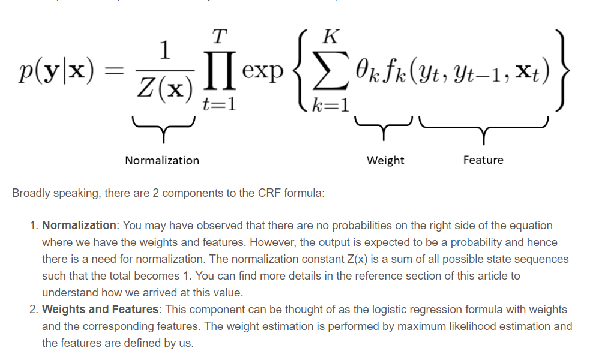

Each of the feature-based models use the same Viterbi algorithm to find the probability of the best tag sequence. A sequence classifier like an MEMM can be trained to label new sentences. In the below example, the operation of a sequence labeler is at the point where the token *Corp.* is next to be labeled. Everything in the boxed area is the features available to the classifier.

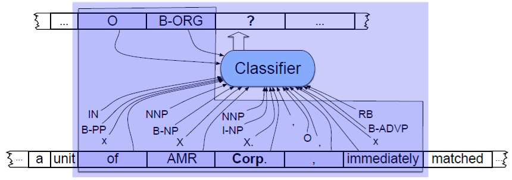

## Neural Algorithm for NER

As CRFs have to rely on gazetteers and lists, this is a sub-prime solution as there are numerous flaws with these lists in terms of the costs of maintaining and updating the lists as well as lists not capturing every entity. NLP experts have begun to use recurrent neural networks for NER because of their ability to handle sequential data.

The neural algorithm normally used for NER is a bi-directional Long Short Term Memory (bi-LSTM) which divides the text into two portions: one in which the data is no longer needed and “discarded” and one which keeps information that will likely be used later. Of the words it keeps, it maps each of the words into their word embeddings (which are vectors of real numbers). This can be accomplished in numerous packages like word2vec.

The neural net then uses the bi-directional LSTM layers which read each embedding and give an output after each hidden layer. A dense layer then takes its weights and maps outputs of the bi-LSTM layers to a *n*-dimensional vector of logits and probabilities, thus identifying the entity, entity type, and non-NER tokens.

Two graphical depictions of the bi-LSTM model are shown below:

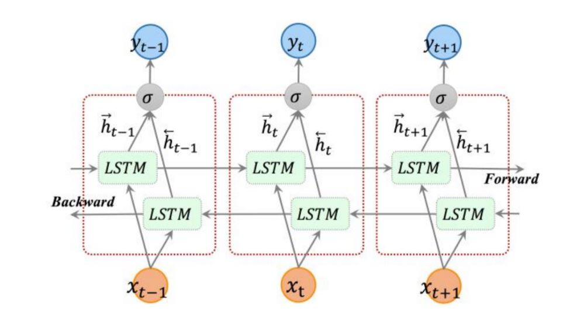

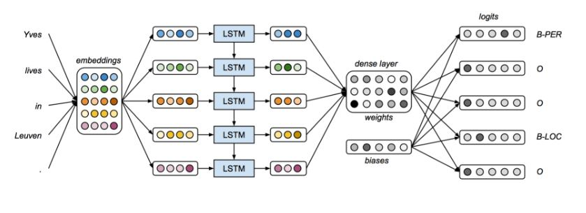

The benefits of using a bi-direction neural net is that not only are words after the token of interest considered, but words before the token of interest are also considered, allowing the model to uncover more patterns in the data.(4) This makes the RNN much more accurate, with a much higher $F_1$ measure than a normal LSTM model.

## Rule-based NER

Machine learned (neural or MEMM/CRF) sequence models are common in academic research, but for commercial use, NER is often based on pragmatic combinations of lists and rules. These lists or rules are either hand-coded or developed from examples. Typical rule-based systems consist of:

- a collection of rules
- a set of policies to control the firing of multiple rules

Single-entry rules tend to have the form *Contextual Pattern* -> *Action*. Take for example the line “at 3 pm will”. A rule could be implemented to identify the entity “3 pm” as a standard time. The rule would first look for a pre word of “at”, a fill of a positive digit and then a time id, and post part of speech auxiliary verb (AUX).

Rule-based NER will typically make repeated passes over text and uses previous results of one pass to influence the next.

1. Use high-precision rules to tag unambiguous entity mentions.
2. Search for substring matches of the previously detected names.
3. Consult application-specific name lists to identify likely name entity mentions from the given domain.
4. Apply probabilistic sequence labeling techniques that make use of the tags from previous stages as additional features.

These more in depth steps of rule based incorporate multiple entity rules and which rules should be applied over a larger span of text (longer entities).

## Evaluation Methods

NER systems are evaluated by recall, precision, and $F_1$ measure. Recall is the ratio of the number of correctly labeled responses to the total that could have been labeled in the text. It is the measure of how much relevant information the system has extracted (coverage of system).

Precision is the ratio of the number of correctly labeled responses to the total actually labeled by the system. It is the measure of how much of the information the system returned is correct (accuracy). The F-measure is the harmonic mean of the two. These metrics all treat the entities as the response rather than the words.

There is mismatch between the training and test conditions that develops from using the entities as the response units. Also, the segmentation done in NER can create undue error. For example, identifying the entity *American* as an organization instead of *America Airlines* would cause two errors:

- a false positive for an Organization entity
- a false negative for I-Organization (Airlines)

## Applications of NER

NER can be used to filter out entities from documents and then further NLP tasks can be performed on the entities, such as:

- Question answering
- Text summarization
- Sentiment analysis

Search engine algorithms can apply NER to shorten the lengthy query of articles. NER can be applied to each article and entities saved to identify a given article. The key tags in the search query can then be compared with the tags associated with the website articles for a quick and efficient search.

Recommendations on websites can be developed using NER to automatically filter relevant content a person might want to view. The entities associated with content in someone’s history can be compared with labels assigned to other content to make recommendations.

NER can aid a company’s hiring process by simplifying resumes down to entities. A company’s customer service complaints or feedback can be classified by their entities and directed to the proper departments.

# Conclusions

NER, much like parts of speech, has many uses in and of itself but can also be used to filter documents and run further NLP tasks on. Though NER can be very helpful to gain insight about a document or use it as a filter to perform other NLP tasks, it is certainly not without its faults. Language complexities, different abbreviations, and a vast array of entities having many different meanings will always make NER very difficult. Advancement of neural networks and updated lists and gazetteers will continue to make NER more accurate but it is important for analysts to remember these neural networks and other modelling techniques won’t be perfect.

# References

1. Speech and Language Processing. Jurafsky, Daniel and Martin, James H. Draft Date: September 23, 2018.
2. [Named Entity Recognition: Applications and Use Cases](https://dzone.com/articles/named-entity-recognition-applications-and-use-case)
3. [Named Entity Recognition](https://www.kiv.zcu.cz/site/documents/verejne/vyzkum/publikace/technicke-zpravy/2012/tr-2012-04.pdf)
4. [Deep Learning for Named Entity Recognition #2: Implementing the state-of-the-art Bidirectional LSTM + CNN model for CoNLL 2003](https://towardsdatascience.com/deep-learning-for-named-entity-recognition-2-implementing-the-state-of-the-art-bidirectional-lstm-4603491087f1)
5. [Named Entity Recognition and the Road to Deep Learning](http://nlp.town/blog/ner-and-the-road-to-deep-learning/)
6. [A Review of Named Entity Recognition (NER) Using Automatic Summarization of Resumes](https://towardsdatascience.com/a-review-of-named-entity-recognition-ner-using-automatic-summarization-of-resumes-5248a75de175)
7. [Information Extraction: Lecture 3 – Rule-based Named Entity Recognition](http://www.cis.uni-muenchen.de/~fraser/information_extraction_2015_lecture/03_rule_based_NER.pdf)
8. [Conditional Random Fields - Stanford University (By Daphne Koller)](https://www.youtube.com/watch?v=rc3YDj5GiVM)
9. [An Intuitive Understanding of Word Embeddings](https://www.analyticsvidhya.com/blog/2017/06/word-embeddings-count-word2veec/)
10. [Statistical Methods for NLP](http://www.cs.columbia.edu/~smaskey/CS6998/slides/statnlp_week10.pdf)
11. [Conditional Random Fields: Probabilistic Models for Segmenting and Labeling Sequence Data](https://repository.upenn.edu/cgi/viewcontent.cgi?article=1162&context=cis_papers)
12. [OpenNLP Tutorial](https://www.tutorialspoint.com/opennlp/)
13. [An Introduction to Conditional Random Fields](http://homepages.inf.ed.ac.uk/csutton/publications/crftut-fnt.pdf)

# Named Entity Recognition using openNLP

In order for openNLP to work, you must first download the following package

```r
options( java.parameters = "-Xmx5120m" )
install.packages("openNLPmodels.en", repos = "http://datacube.wu.ac.at/",type = "source")
```

Next, load the following packages, or call them from the library.

```r
#pacman::p_install(c("openNLP","coreNLP","readr","NLP","monkeylearn","magrittr"))

# Or if you already have them installed, just load the libraries

library(openNLP)
library(NLP)
library(coreNLP)
library(monkeylearn)
library(readr)
library(magrittr)
options( java.parameters = "-Xmx5120m" )
library(rJava)
```

Now that the packages are loaded, we need to insert the text documents

```r
rem <- readr::read_file("Remington.txt")
title <- c()
for (i in 1:4){
  j=1989
  title[i] <- paste("Bush_",j,".txt", sep = "")
  title <- c(title)
  j <- j + 1
}

title2 <- c()
for (i in 1:4){
  k=2001
    title2[i] <- paste("Bush_",k,".txt", sep = "")
  title2 <- c(title2)
  k <- k + 1
}


all <- c(title,title2)
speech <- c()
for (i in seq_along(all)){

  speech[i] <- read_file(all[i])
  i <- i + 1
}
```

# Named Entity Recognition using coreNLP

## Download coreNLP

```r
pacman::p_load("rJava")
#               "coreNLP")
devtools::install_github('statsmaths/coreNLP')
#install.packages("coreNLP")
```

There is a coreNLP package on CRAN but the only the developmental github version will complete sentiment analysis when I tested between the two.

```r
coreNLP::downloadCoreNLP() # creating an instance (opening the pipeline)
```

```
[1] 0
```

```r
coreNLP::initCoreNLP()
str <- c("President George Bush spoke to the troops on board of an aircraft carrier in the Gulf of Mexico.")
library(coreNLP)
output <- coreNLP::annotateString(str)
NER <- coreNLP::getToken(output)
NER[,c("sentence","id","token","POS","NER")]
```

```
   sentence id     token POS      NER
1         1  1 President NNP        O
2         1  2    George NNP   PERSON
3         1  3      Bush NNP   PERSON
4         1  4     spoke VBD        O
5         1  5        to  TO        O
6         1  6       the  DT        O
7         1  7    troops NNS        O
8         1  8        on  IN        O
9         1  9     board  NN        O
10        1 10        of  IN        O
11        1 11        an  DT        O
12        1 12  aircraft  NN        O
13        1 13   carrier  NN        O
14        1 14        in  IN        O
15        1 15       the  DT        O
16        1 16      Gulf NNP LOCATION
17        1 17        of  IN LOCATION
18        1 18    Mexico NNP LOCATION
19        1 19         .   .        O
```

```r
# word character. Raw word in the input text.
# lemma character. Lemmatized form the token.
```

The Stanford typed dependencies representation was designed to provide a simple description of the grammatical relationships in a sentence that can easily be understood and effectively used by people without linguistic expertise who want to extract textual relations. In particular, rather than the phrase structure representations that have long dominated in the computational linguistic community, it represents all sentence relationships uniformly as typed dependency relations.The current representation contains approximately 50 grammatical relations (depending slightly on the options discussed in section 4). The dependencies are all binary relations: a grammatical relation holds between a governor (also known as a regent or a head) and a dependent. Further explanation of dependencies can be found in References [(1)](https://nlp.stanford.edu/software/dependencies_manual.pdf).

```r
# Returns a data frame of the coreferences of an annotation
coreNLP::getDependency(output)
```

```
   sentence governor dependent     type governorIdx dependentIdx govIndex
1         1     ROOT     spoke     root           0            4       NA
2         1     Bush President compound           3            1        3
3         1     Bush    George compound           3            2        3
4         1    spoke      Bush    nsubj           4            3        4
5         1   troops        to     case           7            5        7
6         1   troops       the      det           7            6        7
7         1    spoke    troops  nmod:to           4            7        4
8         1    board        on     case           9            8        9
9         1   troops     board  nmod:on           7            9        7
10        1  carrier        of     case          13           10       13
11        1  carrier        an      det          13           11       13
12        1  carrier  aircraft compound          13           12       13
13        1    board   carrier  nmod:of           9           13        9
14        1     Gulf        in     case          16           14       16
```

[output cut: 25 more lines]

StanfordCoreNLP includes the sentiment tool and various programs which support it. The model can be used to analyze text as part of StanfordCoreNLP by adding “sentiment” to the list of annotators. There is also command line support and model training support.

SentimentAnnotator implements Socher et al’s sentiment model. Attaches a binarized tree of the sentence to the sentence level CoreMap. The nodes of the tree then contain the annotations from RNNCoreAnnotations indicating the predicted class and scores for that subtree [(2)](https://stanfordnlp.github.io/CoreNLP/sentiment.html).

```r
coreNLP::getSentiment(output)
```

```
  id sentimentValue sentiment
1  1              1  Negative
```

## Applied to Remington Text

```r
rem_output <- coreNLP::annotateString(rem)
rem_output$token
```

```
         sentence id                                               token
1               1  1                                           Remington
2               1  2                                                   ,
3               1  3                                                 the
4               1  4                                                 Gun
5               1  5                                               Maker
6               1  6                                                   ,
7               1  7                                                  Is
8               1  8                                                 Set
9               1  9                                                  to
10              1 10                                                Exit
11              1 11                                          Bankruptcy
12              1 12                                           Remington
13              1 13                                             Outdoor
14              1 14                                                   ,
```

[output cut: 1848 more lines]

```r
rem_NER <- coreNLP::getToken(rem_output)
table(rem_NER$NER)
```

```
        DATE     DURATION     LOCATION         MISC        MONEY
          22            2           10            7            6
      NUMBER            O ORGANIZATION       PERSON
           5          526           30           12
```

```r
people_rem <- subset(rem_NER, NER=="PERSON")
(people_rem)
```

```
    sentence id     token     lemma CharacterOffsetBegin
1          1  1 Remington Remington                    0
60         2 10 Remington Remington                  328
91         3  1 Remington Remington                  495
143        5  4 Remington Remington                  785
316       11  8  Marianne  Marianne                 1778
317       11  9      Lake      Lake                 1787
363       13  7    Thomas    Thomas                 2046
364       13  8        P.        P.                 2053
365       13  9  DiNapoli  DiNapoli                 2056
418       14  2  DiNapoli  DiNapoli                 2366
490       16  6     Trump     Trump                 2774
570       19  1 Remington Remington                 3182
    CharacterOffsetEnd POS    NER Speaker
1                    9 NNP PERSON    PER0
60                 337 NNP PERSON    PER0
91                 504 NNP PERSON    PER0
143                794 NNP PERSON    PER0
316               1786 NNP PERSON    PER0
317               1791 NNP PERSON    PER0
363               2052 NNP PERSON    PER0
364               2055 NNP PERSON    PER0
365               2064 NNP PERSON    PER0
418               2374 NNP PERSON    PER0
490               2779 NNP PERSON    PER0
570               3191 NNP PERSON    PER0
```

```r
library(tidyr)
rem_sent <- coreNLP::getSentiment(rem_output)
rem_sent
```

```
   id sentimentValue    sentiment
1   1              0 Verynegative
2   2              1     Negative
3   3              1     Negative
4   4              1     Negative
5   5              1     Negative
6   6              2      Neutral
7   7              1     Negative
8   8              1     Negative
9   9              1     Negative
10 10              1     Negative
11 11              1     Negative
12 12              1     Negative
13 13              0 Verynegative
14 14              1     Negative
15 15              1     Negative
16 16              1     Negative
17 17              1     Negative
18 18              1     Negative
19 19              1     Negative
20 20              1     Negative
21 21              2      Neutral
```

```r
# 21 sentences identified in the beginning
```

# Challenges of Named Entity Recognition

```r
#first set the document as one string
s <- as.String(rem)
```

Next, we need to use the maximum entropy functions in openNLP to annotate the Remington document.

```r
library(openNLP)
sent_token_annotator <- Maxent_Sent_Token_Annotator()
word_token_annotator <- Maxent_Word_Token_Annotator()

a2 <- annotate(s, list(sent_token_annotator, word_token_annotator))
```

Let’s first look at the person entities

```r
## Entity recognition for persons.
entity_annotator <- openNLP::Maxent_Entity_Annotator()
annotate(s, entity_annotator, a2)
```

```
 id  type     start end  features
   1 sentence     1  278 constituents=<<integer,49>>
   2 sentence   281  493 constituents=<<integer,40>>
   3 sentence   496  669 constituents=<<integer,30>>
   4 sentence   671  763 constituents=<<integer,16>>
   5 sentence   766  844 constituents=<<integer,15>>
   6 sentence   846  898 constituents=<<integer,10>>
   7 sentence   901 1153 constituents=<<integer,45>>
   8 sentence  1156 1375 constituents=<<integer,33>>
   9 sentence  1377 1513 constituents=<<integer,20>>
  10 sentence  1516 1743 constituents=<<integer,40>>
  11 sentence  1746 1949 constituents=<<integer,33>>
  12 sentence  1952 2013 constituents=<<integer,11>>
  13 sentence  2015 2360 constituents=<<integer,60>>
  14 sentence  2363 2549 constituents=<<integer,30>>
```

[output cut: 608 more lines]

```r
## Directly:
entity_annotator(s, a2)
```

```
 id  type   start end  features
 620 entity  1169 1177 kind=person
 621 entity  1559 1571 kind=person
 622 entity  2047 2064 kind=person
```

```r
## And slice ...
s[entity_annotator(s, a2)]
```

```
[1] "Citigroup"          "Vista Outdoor"      "Thomas P. DiNapoli"
```

Next, the location entities

```r
#Entity recognition for locations
entity_annotator_location <- Maxent_Entity_Annotator(kind = "location")
annotate(s, entity_annotator_location, a2)
```

```
 id  type     start end  features
   1 sentence     1  278 constituents=<<integer,49>>
   2 sentence   281  493 constituents=<<integer,40>>
   3 sentence   496  669 constituents=<<integer,30>>
   4 sentence   671  763 constituents=<<integer,16>>
   5 sentence   766  844 constituents=<<integer,15>>
   6 sentence   846  898 constituents=<<integer,10>>
   7 sentence   901 1153 constituents=<<integer,45>>
   8 sentence  1156 1375 constituents=<<integer,33>>
   9 sentence  1377 1513 constituents=<<integer,20>>
  10 sentence  1516 1743 constituents=<<integer,40>>
  11 sentence  1746 1949 constituents=<<integer,33>>
  12 sentence  1952 2013 constituents=<<integer,11>>
  13 sentence  2015 2360 constituents=<<integer,60>>
  14 sentence  2363 2549 constituents=<<integer,30>>
```

[output cut: 608 more lines]

```r
## Directly:
entity_annotator_location(s, a2)
```

```
 id  type   start end  features
 620 entity   306  313 kind=location
 621 entity  2842 2848 kind=location
 622 entity  3116 3124 kind=location
```

```r
## And slice ...
s[entity_annotator_location(s, a2)]
```

```
[1] "Delaware"  "Madison"   "Remington"
```

Next, the organization entities

```r
#Entity Recognition for Organizations
entity_annotator_org <- Maxent_Entity_Annotator(kind = "organization")
annotate(s, entity_annotator_org, a2)
```

```
 id  type     start end  features
   1 sentence     1  278 constituents=<<integer,49>>
   2 sentence   281  493 constituents=<<integer,40>>
   3 sentence   496  669 constituents=<<integer,30>>
   4 sentence   671  763 constituents=<<integer,16>>
   5 sentence   766  844 constituents=<<integer,15>>
   6 sentence   846  898 constituents=<<integer,10>>
   7 sentence   901 1153 constituents=<<integer,45>>
   8 sentence  1156 1375 constituents=<<integer,33>>
   9 sentence  1377 1513 constituents=<<integer,20>>
  10 sentence  1516 1743 constituents=<<integer,40>>
  11 sentence  1746 1949 constituents=<<integer,33>>
  12 sentence  1952 2013 constituents=<<integer,11>>
  13 sentence  2015 2360 constituents=<<integer,60>>
  14 sentence  2363 2549 constituents=<<integer,30>>
```

[output cut: 612 more lines]

```r
## Directly:
entity_annotator_org(s, a2)
```

```
 id  type   start end  features
 620 entity   642  667 kind=organization
 621 entity  1262 1276 kind=organization
 622 entity  2019 2032 kind=organization
 623 entity  2228 2242 kind=organization
 624 entity  2248 2258 kind=organization
 625 entity  3052 3079 kind=organization
 626 entity  3255 3279 kind=organization
```

```r
## And slice ...
s[entity_annotator_org(s, a2)]
```

```
[1] "Cerberus Capital Managemen"   "Bank of America"
[3] "New York State"               "Bank of America"
[5] "Wells Fargo"                  "Sandy Hook Elementary School"
[7] "Connecticut Supreme Court"
```

Finally, the date entities

```r
#Entity Recognition for dates
entity_annotator_date <- Maxent_Entity_Annotator(kind = "date")
annotate(s, entity_annotator_date, a2)
```

```
 id  type     start end  features
   1 sentence     1  278 constituents=<<integer,49>>
   2 sentence   281  493 constituents=<<integer,40>>
   3 sentence   496  669 constituents=<<integer,30>>
   4 sentence   671  763 constituents=<<integer,16>>
   5 sentence   766  844 constituents=<<integer,15>>
   6 sentence   846  898 constituents=<<integer,10>>
   7 sentence   901 1153 constituents=<<integer,45>>
   8 sentence  1156 1375 constituents=<<integer,33>>
   9 sentence  1377 1513 constituents=<<integer,20>>
  10 sentence  1516 1743 constituents=<<integer,40>>
  11 sentence  1746 1949 constituents=<<integer,33>>
  12 sentence  1952 2013 constituents=<<integer,11>>
  13 sentence  2015 2360 constituents=<<integer,60>>
  14 sentence  2363 2549 constituents=<<integer,30>>
```

[output cut: 616 more lines]

```r
## Directly:
entity_annotator_date(s, a2)
```

```
 id  type   start end  features
 620 entity   130  138 kind=date
 621 entity   318  326 kind=date
 622 entity   545  549 kind=date
 623 entity  1020 1027 kind=date
 624 entity  1156 1166 kind=date
 625 entity  1522 1529 kind=date
 626 entity  1580 1583 kind=date
 627 entity  1767 1776 kind=date
 628 entity  2140 2150 kind=date
 629 entity  2860 2863 kind=date
 630 entity  2996 2999 kind=date
```

```r
## And slice ...
s[entity_annotator_date(s, a2)]
```

```
 [1] "this week"   "Wednesday"   "March"       "February"    "This spring"
 [6] "February"    "this"        "last month"  "this spring" "2007"
[11] "2012"
```